# Previsão do MAPE de modelos empíricos de emissão de metano

IME0546 — Tópicos em Matemática Aplicada · Rede Global de Nutrição Animal (treino)

11/09/2026

# 1 Anatomia da Variável Alvo

O foco principal deste estudo preditivo reside na modelagem do **Mean Absolute Percentage Error (MAPE)** correspondente aos cinco modelos empíricos ajustados para a estimativa de emissões de metano entérico em bovinos. É de extrema relevância salientar que o alvo sob investigação **não é a emissão absoluta do gás**, mas sim a magnitude do erro percentual absoluto associado a cada formulação empírica.

Como as predições de regressão clássicas serão avaliadas em múltiplos cenários regionais, o objetivo é compreender os fatores individuais do animal que ditam o comportamento de erro de cada modelo empírico.

A análise univariada do MAPE na escala original revelou um perfil de distribuição altamente desafiador para modelagens lineares clássicas. A distribuição apresenta forte **assimetria positiva (à direita)**, com média amostral de **0,229** superando consideravelmente a mediana de **0,186**. Adicionalmente, identificou-se uma cauda longa extrema, onde o erro máximo observado atinge a marca de **1,214** (erro superior a 120%), enquanto o limite inferior está estritamente contido no domínio dos reais positivos $(MAPE > 0)$.

Essa assimetria acentuada violaria de forma grave a premissa de homocedasticidade e normalidade dos resíduos de modelos estimados por Mínimos Quadrados Ordinários (OLS). Para contornar essa restrição e estabilizar a variância do alvo ao longo de diferentes patamares, aplicou-se a **transformação matemática de Box-Cox**.

A busca de máxima verossimilhança estimou o parâmetro ótimo de inclinação em **$(\lambda \approx 0,343$)**. A transformação do vetor alvo para a modelagem segue formalmente a equação:

$$Y^{(\lambda)} = \begin{cases}
\frac{\text{MAPE}^{\lambda} - 1}{\lambda}, & \text{se } \lambda \neq
0 \\
\ln(\text{MAPE}), & \text{se } \lambda = 0
\end{cases}$$

## 1.1 Visualização e Análise do MAPE

A cauda longa à direita fica evidente ao plotarmos o histograma de frequências do MAPE bruto na base de treino:

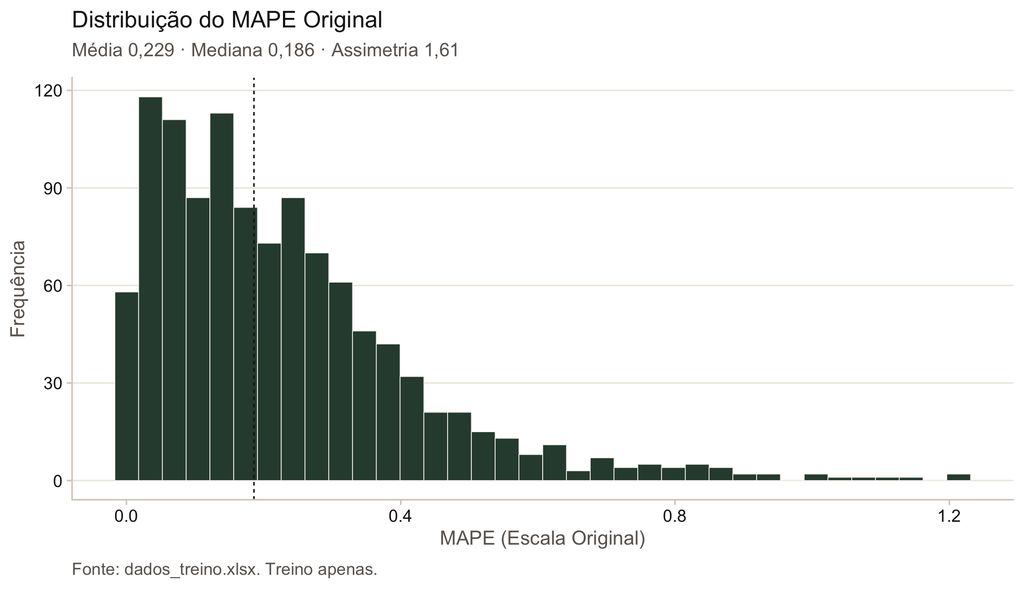

Histograma do MAPE no treino (1.115 linhas). A linha tracejada representa a mediana.

Resumo univariado do MAPE na escala física original.

| n | media | mediana | desvio | q1 | q3 | minimo | maximo | assimetria | n_nao_positivo |
| --- | --- | --- | --- | --- | --- | --- | --- | --- | --- |
| 1115 | 0,229 | 0,186 | 0,192 | 0,085 | 0,315 | 0,000 | 1,214 | 1,609 | 0 |

## 1.2 Transformação de Box-Cox ($\lambda \approx 0,343$)

Com a aplicação do parâmetro ótimo encontrado por máxima verossimilhança, a distribuição foi centralizada e a assimetria caus de $+1,61$ para $-0,17$, resultando em uma distribuição com propriedades matemáticas ideais para ajustes lineares:

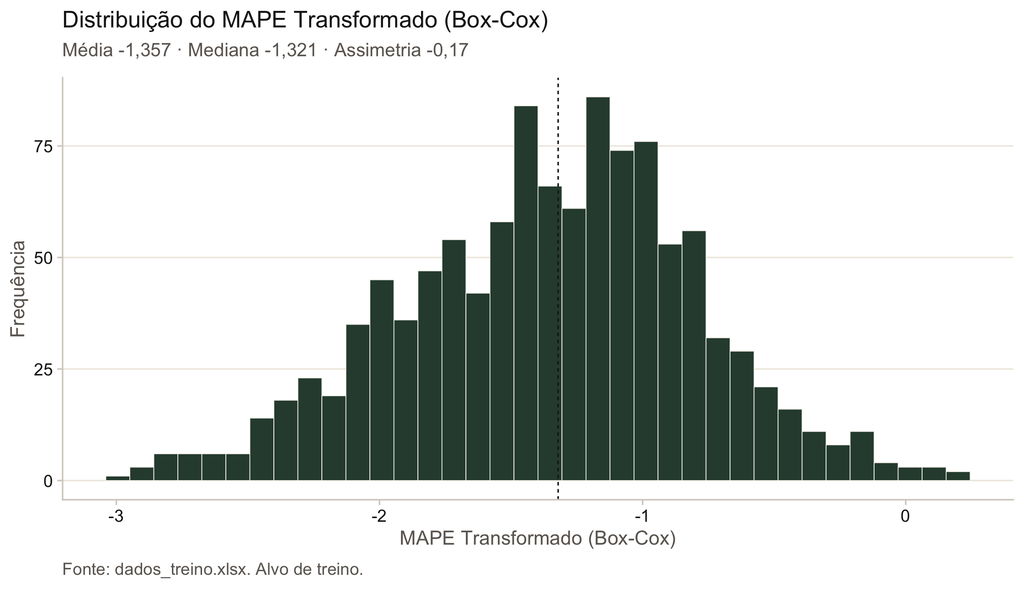

Histograma do MAPE-BOXCOX no treino (1.115 linhas) sob o lambda ótimo.

Resumo univariado do MAPE transformado por Box-Cox.

| n | media | mediana | desvio | q1 | q3 | minimo | maximo | assimetria | n_nao_positivo |
| --- | --- | --- | --- | --- | --- | --- | --- | --- | --- |
| 1115 | -1,357 | -1,321 | 0,562 | -1,740 | -0,975 | -2,994 | 0,199 | -0,172 | 1108 |

Por fim, ao analisar a densidade do alvo transformado por modelo empírico, observa-se que, embora a compressão da cauda longa tenha sido uniformemente aplicada com sucesso em todas as formulações, o centro de massa da distribuição de erros difere nitidamente de modelo para modelo, justificando o esforço de predição e seleção personalizada.

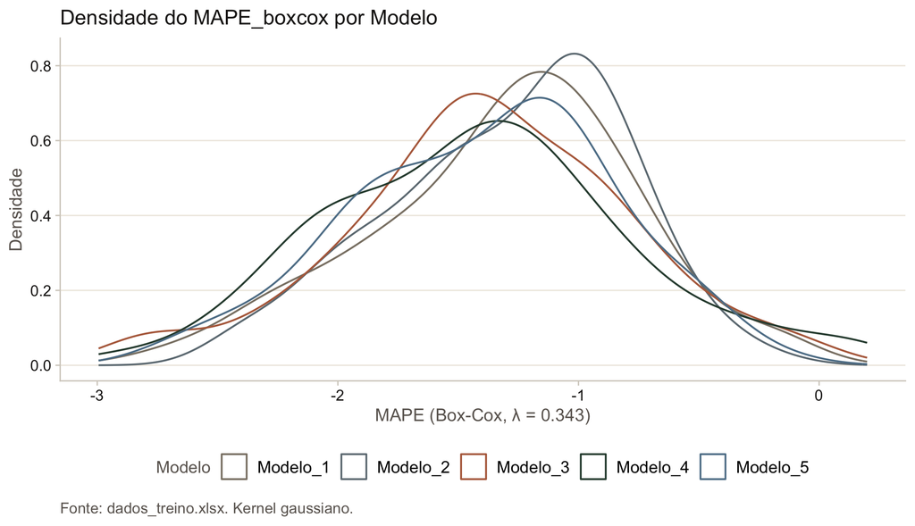

Densidade do MAPE transformado (Box-Cox) por modelo empírico.

# 2 Variância Hierárquica e Dependência de Grupo

## 2.1 Avaliação da Estrutura dos Dados

Na modelagem de dados zootécnicos provenientes de consórcios internacionais, um erro frequente é assumir que as observações são independentes e identicamente distribuídas ($i.i.d.$). No presente dataset de treino, as $1.115$ linhas representam, na verdade, a avaliação de $5$ modelos empíricos aplicados de forma pareada sobre os mesmos $223$ animais. Estes animais, por sua vez, estão aninhados em $93$ **Estudos** diferentes conduzidos ao redor do mundo.

Se tratássemos cada linha de erro ($ID\_Observacao \times Modelo$) como uma observação independente em uma validação cruzada clássica (K-Fold aleatório por linha), incorreríamos em dois problemas graves:

1. **Dependência pareada intrínseca:** Os cinco erros calculados para o mesmo animal compartilham a mesma genética, peso e metabolismo do hospedeiro, gerando resíduos altamente correlacionados.
2. **Dependência hierárquica ambiental:** Animais pertencentes ao mesmo Estudo compartilham a mesma dieta, temperatura, manejo e protocolo laboratorial de medição de metano.

Se o modelo de Machine Learning “decorasse” características específicas de um estudo no conjunto de treino e fosse testado em observações desse mesmo estudo, as métricas de validação seriam ilusoriamente otimistas (vazamento de dados ou *data leakage*). Portanto, precisamos testar a capacidade do seletor de generalizar para estudos científicos completamente inéditos.

## 2.2 Decomposição de Soma de Quadrados via ANOVA One-way

Para quantificar estatisticamente a influência do agrupamento dos estudos sobre a variabilidade do erro, realizou-se uma Análise de Variância (ANOVA) de um fator, tendo o MAPE bruto como variável dependente e o `Estudo` como fator de agrupamento.

Tabela ANOVA One-way para decomposição do MAPE em função do Estudo.

| Fonte | gl | Soma de quadrados | Fração da SQ |
| --- | --- | --- | --- |
| Estudo (Entre estudos) | 92 | 23,525 | 57,4% |
| Residual (Dentro do estudo) | 1022 | 17,469 | 42,6% |

A decomposição revela que o fator Estudo responde por **57,4% de toda a Soma de Quadrados total** observado no MAPE do dataset de treino. Isso indica que mais da metade da flutuação de erro não tem origem nas características individuais do animal (como peso corporal), mas sim em fatores sistêmicos e metodológicos de cada ensaio experimental.

## 2.3 Cálculo do Coeficiente de Correlação Intraclasse (ICC)

Como o número de animais e observações varia entre os experimentos, temos um delineamento não-balanceado. Para calcular o **Coeficiente de Correlação Intraclasse (ICC)** de forma robusta e sem viés, o código adota a formulação clássica de Searle para o tamanho amostral equivalente ($n_0$) sob desbalanceamento, aplicando o Método dos Momentos para estimar os componentes de variância:

$$n_0 = \frac{N - \frac{\sum_{i}
n_i^2}{N}}{k - 1}$$

$$\hat{\sigma}^2_b = \max\left(0,
\frac{MS_E - MS_R}{n_0}\right)$$

$$\widehat{\text{ICC}} =
\frac{\hat{\sigma}^2_b}{\hat{\sigma}^2_b +
\hat{\sigma}^2_w}$$

Onde:

- $N$ representa o total de observações ($1.115$);
- $k$ representa o número de estudos únicos ($93$);
- $n_i$ é o número de observações dentro do estudo $i$ (sempre múltiplo de $5$);
- $MS_E$ é o Quadrado Médio Entre estudos ($MS_E = SS_E / (k - 1)$);
- $MS_R$ é o Quadrado Médio Residual (Dentro do estudo, $MS_R = SS_R / (N - k)$);
- $\hat{\sigma}^2_b$ representa o componente de variância entre estudos;
- $\hat{\sigma}^2_w$ representa o componente de variância residual dentro dos estudos.

O processamento dinâmico dos dados de treino resultou em um **ICC de 0,539 (com $n_0 \approx 11,94$, $\hat{\sigma}^2_b \approx 0,0200$ e $\hat{\sigma}^2_w \approx 0,0171$).

O ICC de **0,539** confirma que aproximadamente **53,9%** da variância total do MAPE é decorrente puramente do efeito de agrupamento dos estudos. Isso atesta de forma definitiva a dependência hierárquica dos resíduos e impede o uso de validações cruzadas simples que violem essa estrutura.

## 2.4 Protocolo de Validação Cruzada

Diante desse cenário hierárquico, o script de modelagem em Python (`04_modelagem_validacao.py`) foi travado sob dois protocolos de validação cruzada de alta rigidez para garantir que o modelo seja testado em ambientes que imitam o teste lacrado:

1. **`GroupKFold` por Estudo (5 folds):** Garante que o dataset de treino seja particionado de forma que estudos inteiros sejam isolados. Se o *Estudo A* for selecionado para o fold de validação, nenhum animal pertencente ao *Estudo A* poderá compor o conjunto de treino desse fold.
2. **`Leave-One-Study-Out` (LOSO) para os Países do Case:** Este protocolo simula o cenário de aplicação real do teste oculto. Para os estudos pertencentes aos cinco países ocultos do case (Campo Rico, Costa Austral, Ilha Verdejante, Monção Dourada e Terra Nortenha), o modelo é validado deixando um estudo local inteiramente de fora para teste, treinando com todos os estudos restantes de todos os outros países.

*Nota de integridade:* É imperativo destacar que a variável categórica `Estudo` é utilizada **unicamente como chave de agrupamento** no iterador da validação cruzada. Ela jamais entra como variável preditora (*feature* ou *dummy*) nos estimadores de regressão, uma vez que estudos futuros no teste lacrado possuirão códigos de identificação inéditos e imprevisíveis para o modelo.

# 3 Engenharia de Features

## 3.1 Eliminação de Redundâncias

Antes de submeter os dados aos estimadores de Machine Learning, as covariáveis contínuas e categóricas do dataset de treino passaram por um rigoroso processo de saneamento metodológico na fase de Engenharia de Features ( `03_engenharia_features.R`). Esse procedimento eliminou ruídos e redundâncias sistêmicas que causariam instabilidade nos coeficientes ou singularidade nas matrizes de covariância dos regressores lineares.

As seguintes variáveis foram descartadas da matriz de preditores ativos por critérios estatísticos formais:

1. **`Sistema_Producao` (Variável Constante):** No dataset de treino, todas as observações registram unicamente a categoria `"Confinamento"`. Sendo sua variância nula ($\sigma^2 = 0$), a variável não possui poder preditivo para diferenciar os patamares de erro entre animais e foi completamente excluída para evitar colunas colineares com o intercepto.
2. **`Fracao_Perda_B` (Redundância Perfeita com Fração A):** A análise bivariada revelou que os vetores de `Fracao_Perda_A` e `Fracao_Perda_B` possuem correlação linear de Pearson de $1,000000$ no treino, sendo indistinguíveis entre si. Para evitar multicolinearidade exata (matriz de especificação sem posto completo), apenas a `Fracao_Perda_A` foi mantida como preditor contínuo.
3. **`Consumo_sobre_peso` (Redundância com Fração A):** A variável derivada de eficiência $\text{Consumo\_MS\_kg} / \text{Peso\_Corporal\_kg}$ gerava VIF infinito nas simulações iniciais. A auditoria matemática constatou empiricamente que essa razão é numericamente idêntica à `Fracao_Perda_A` ($r = 1,000$). Por ser uma duplicação matemática exata em outra escala, foi eliminada na limpeza inicial do R.
4. **`Estudo` (Variável de Agrupamento):** Como demonstrado na Seção 2, o `Estudo` é a nossa chave hierárquica. Ele é utilizado estritamente para estruturar as partições da validação cruzada (`GroupKFold` e `LOSO`), sendo vetado como variável preditora.

Auditoria de redundâncias e colinearidades exatas na base de dados de treino.

| Premissa Auditada | Resultado Calculado | Decisão de Feature Engineering |
| --- | --- | --- |
| Sistema de Produção Único | Sim (Confinamento apenas, n = 1) | Excluir 'Sistema_Producao' do estimador |
| Correlação Linear (Fração A vs Fração B) | 1,000000 | Excluir 'Fracao_Perda_B' (Manter apenas Fração A) |
| Razão Consumo/Peso vs Fração A | Identidade Matemática Exata (r = 1,000) | Excluir 'Consumo_sobre_peso' por redundância exata |

## 3.2 Diagnóstico de Multicolinearidade (VIF) e Grid Search

O fator de inflação da variância (**VIF** - *Variance Inflation Factor*) quantifica o grau em que a variância de um coeficiente de regressão estimado é inflacionada devido à colinearidade com as demais variáveis independentes do modelo:

$$\text{VIF}_j = \frac{1}{1 -
R^2_j}$$

No presente estudo, identificou-se uma forte correlação biológica entre `Peso_Corporal_kg` e `Consumo_MS_kg` ($r = 0,53$). Ao calcular o VIF bruto para os três preditores numéricos concorrentes (`Consumo_MS_kg`, `Peso_Corporal_kg` e `Fracao_Perda_A`), todas as variáveis superaram o limiar de alerta de $5,0$:

- $\text{VIF}_{\text{Consumo}} = 8,70$ ($R^2_{\text{auxiliar}} = 0,89$)
- $\text{VIF}_{\text{Peso}} = 8,65$ ($R^2_{\text{auxiliar}} = 0,88$)
- $\text{VIF}_{\text{Fração A}} = 7,91$ ($R^2_{\text{auxiliar}} = 0,87$)

Para lidar com esse acoplamento no pipeline Python, a variável bruta `Consumo_MS_kg` é preservada na base processada (`03_modelagem.csv`) e mantida em `config.NUM_CANDIDATES`. Isso permite que o *grid search* do `04_modelagem_validacao.py` avalie empiricamente o *tradeoff* entre ganho informacional e inflação do VIF. No estimador linear principal, o consumo bruto é desativado, mantendo-se **`Peso_Corporal_kg`** e **`Fracao_Perda_A`**, o que reduz o VIF multivariado para um patamar seguro de **$\approx 1,26$**.

Para evitar decisões rígidas e a priori sobre o descarte de variáveis relevantes, o pipeline em Python ( `04_modelagem_validacao.py`) faz uma **varredura exaustiva (*grid search*)**. O algoritmo avalia empiricamente os modelos em múltiplos subconjuntos de *features* — comparando especificações saneadas contendo apenas **`Peso_Corporal_kg`** e **`Fracao_Perda_A`** **($VIF = 1,26$)** contra especificações completas que incorporam o consumo —, permitindo medir na validação cruzada se o ganho de informação do consumo compensa a inflação de variância do estimador.

Diagnóstico Comparativo de Inflação de Variância (VIF) no treino.

| Cenário de Modelagem | Variável Alvo | R² Auxiliar | VIF Calculado | Status de Alerta |
| --- | --- | --- | --- | --- |
| Bruto (Três Preditores) | Consumo_MS_kg | 0,885 | 8,70 | VIF >= 5 (Crítico) |
| Bruto (Três Preditores) | Peso_Corporal_kg | 0,884 | 8,65 | VIF >= 5 (Crítico) |
| Bruto (Três Preditores) | Fracao_Perda_A | 0,874 | 7,91 | VIF >= 5 (Crítico) |
| Saneado (Excluindo Consumo) | Peso_Corporal_kg | 0,205 | 1,26 | Seguro |
| Saneado (Excluindo Consumo) | Fracao_Perda_A | 0,205 | 1,26 | Seguro |

## 3.3 Tratamento de Países Inéditos no Protocolo LOSO (Prior do Intercepto)

Uma das principais contribuições da arquitetura de validação Leave-One-Study-Out (LOSO) é avaliar a capacidade de generalização do seletor em regiões geográficas completamente não observadas durante a fase de treinamento.

Do ponto de vista algébrico, o modelo com codificação *dummy* para o fator geográfico é expresso por:

$$\hat{y}_i = \beta_0 + \sum_{k} \beta_k
X_{\text{num}, k} + \sum_{p \in \text{Treino}} \gamma_p \cdot
D_{\text{pais}, p} + \sum_{m} \delta_m \cdot D_{\text{modelo},
m}$$

Ao avaliar um ensaio clínico conduzido em um país inédito no conjunto de teste, a codificação categórica em Python ( `OneHotEncoder(handle_unknown='ignore')`) atribui o valor zero a todos os termos do bloco geográfico $(D_{\text{pais}, p} = 0, \forall p)$. Nessas condições, a equação reduz-se a:

$$\hat{y}_i = \beta_0 + \sum_{k} \beta_k
X_{\text{num}, k} + \sum_{m} \delta_m \cdot D_{\text{modelo},
m}$$

**Interpretação Econométrica:**

O ato de “cair no intercepto” $(\beta_0)$ equivale a adotar um **prior neutro não-informativo** para a geografia. Sob ausência total de histórico experimental naquele país específico, o estimador assume imparcialmente que o desvio geográfico local é nulo $(\gamma_{\text{novo}} = 0)$. A recomendação do modelo empírico passa a ser guiada estritamente pelas características biológicas individuais do animal (peso, consumo e fração de perda) e pelas diferenças estruturais entre as equações empíricas, garantindo robustez e impedindo que vieses de outros países contaminem a previsão.

# 4 Estratégias de Modelagem

## 4.1 Baseline de Mediana por Modelo

- **Lógica Computacional (`baseline_predict`):** Para cada equação empírica de emissão de metano (`Modelo_1` a `Modelo_5`), o estimador atribui a mediana histórica do erro (MAPE) calculada no conjunto de treino daquele fold específico.
- **Função no Pipeline:** Funciona como o *benchmark* mínimo. Qualquer estimador precisa obrigatoriamente superar a acurácia do baseline para comprovar ganho informacional.

## 4.2 Modelagem OLS / Splines

- **Lógica Computacional (`fit_predict_simples`):** Empilham-se todas as $N = 1.115$ observações pareadas da base. Ajusta-se um único pipeline de regressão linear (com ou sem expansão por B-Splines cúbicas na variável Peso Corporal) prevendo a variável alvo transformada $\text{MAPE}_{\text{boxcox}}$ a partir do vetor de características do animal $X_{\text{animal}}$ e do identificador da equação empírica (`Modelo`).
- **Especificação Formal:**

  $$\hat{y}_{ij}= \beta_0 + \sum_{k=1}^{K}
  \beta_k X_{i, k} + \sum_{m=1}^{5} \delta_m D_{ij, m} +
  \epsilon_{ij}$$
- **Onde:**
  - $\hat{y}_{ij}$ é a resposta transformada $\text{MAPE}_{\text{boxcox}}$ do animal $i$ $(i = 1, \dots, 223$) sob o modelo empírico $j$ $(j = 1, \dots, 5$).
  - $X_{i, k}$ é a $k$-ésima covariável biológica do animal $i$ (como Peso Corporal ou expansão em B-Splines).
  - $D_{ij, m}$ é a variável dummy que indica se a observação $ij$ pertence ao modelo empírico $(m$).
  - $\epsilon_{ij}$ é o termo de erro estocástico da observação $ij$.
- **Limitação Metodológica:** Embora simples e direta, essa abordagem trata as $N = 1.115$ linhas como observações independentes $i.i.d.$). Ao fazer isso, ignora a dependência pareada dos 5 modelos ajustados sobre o mesmo animal e a dependência em cluster introduzida pelos 93 estudos $ICC = 0,539$).

## 4.3 Decomposição Sequencial em Dois Estágios (Decomposição do Erro)

Em vez de empilhar as observações em uma regressão OLS direta — o que violaria a suposição de independência dos resíduos $(i.i.d.)$ devido ao alto Coeficiente de Correlação Intraclasse $(\text{ICC} = 0,539)$ —, a arquitetura em dois estágios decompõe a variável alvo transformada $(y = \text{MAPE}_{\text{boxcox}}$) em dois componentes ortogonais:

- **Lógica Computacional (`fit_predict_2sls`):** Em vez de tentar estimar a variância total de uma só vez, a arquitetura decompõe a variável alvo $\text{MAPE}_{\text{boxcox}}$ em dois componentes aditivos e ortogonais:
  - **Estágio 1 (Patamar do Animal):** Agrega os dados no nível do animal $n = 223$, 1 linha por animal, calculando a mediana do erro do animal. Ajusta-se um regressor (OLS ou Spline) sobre as variáveis biológicas do animal $X_{\text{animal}}$), isolando o nível base de erro $\hat{P}_i$.
    $$\hat{P}_i = f\left(X_{\text{animal},
    i}\right)$$
  - **Estágio 2 (Desvio Específico do Modelo):** Retorna-se à base de $N = 1.115$ linhas e calcula-se o resíduo $e_{ij} = y_{ij} - P_i$. Um segundo regressor ajusta os desvios residuais especificamente em função do identificador da equação (`Modelo`) e suas interações com sexo e status metabólico $\hat{D}_{ij}$).
    $$\hat{D}_{ij} = g\left(D_{\text{modelo},
    j}\right)$$
- **Reconstrução Final:** A predição final na escala transformada é obtida pela adição aditiva dos dois estágios, sendo posteriormente convertida de volta à escala física de erro original via inversão de Box-Cox:

  $$\hat{y}_{ij} = \hat{P}_i +
  \hat{D}_{ij}$$

  $$\widehat{\text{MAPE}}_{ij} =
  \text{inv_boxcox}\left(\hat{y}_{ij}\right) = \left(\lambda \cdot
  \hat{y}_{ij} + 1\right)^{1/\lambda}$$

| Estratégia | Dimensão da Base ($N$) | Regressores / Variáveis Utilizadas | Premissa sobre Resíduos ($i.i.d.$) | Objetivo no Pipeline |
| --- | --- | --- | --- | --- |
| **Baseline de Mediana** | $N = 1.115$ | Apenas o indicador do `Modelo` (Mediana) | Assume independência entre folds. | Piso de acurácia (*benchmark* cego). |
| **Estágio Único (OLS / Splines)** | $N = 1.115$ | $X_{\text{animal}}$ + `Modelo` | Viola $i.i.d.$ por ignorar estrutura pareada/cluster. | Testar ajuste direto de parâmetros do animal e fórmula. |
| **Dois Estágios (Decomposição)** | $n = 223$ (E1) $N = 1.115$ (E2) | **E1:** $X_{\text{animal}}$ (sem `Modelo`) **E2:** `Modelo` + Interações sobre o resíduo $e_{ij}$ | Isola o efeito de animal no E1 e modela o desvio relativo no E2. | Isolar patamar do animal e maximizar Acurácia Top-1. |

## 4.4 Flexibilidade Não-Linear via B-Splines direcionadas ao Peso Corporal

No código `pipelines.py`, a função `spline_preprocessor` direciona a expansão por **B-Splines Cúbicas** especificamente à variável **`Peso_Corporal_kg`**.

A transformação utiliza $k = 4$ nós equidistantes e grau polinomial $d = 3$, enquanto a `Fracao_Perda_A` permanece linear para proteger a estabilidade do VIF.

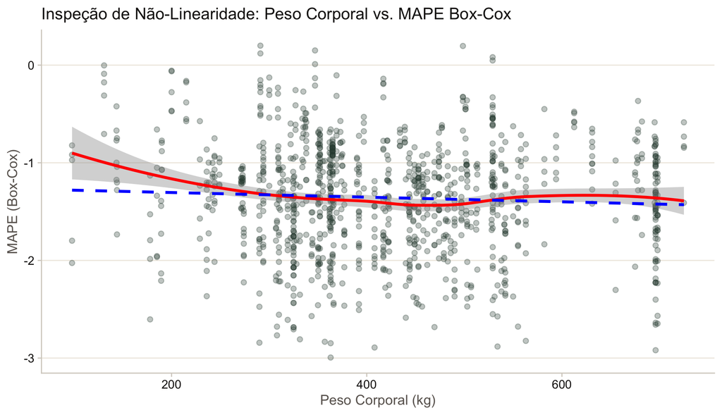

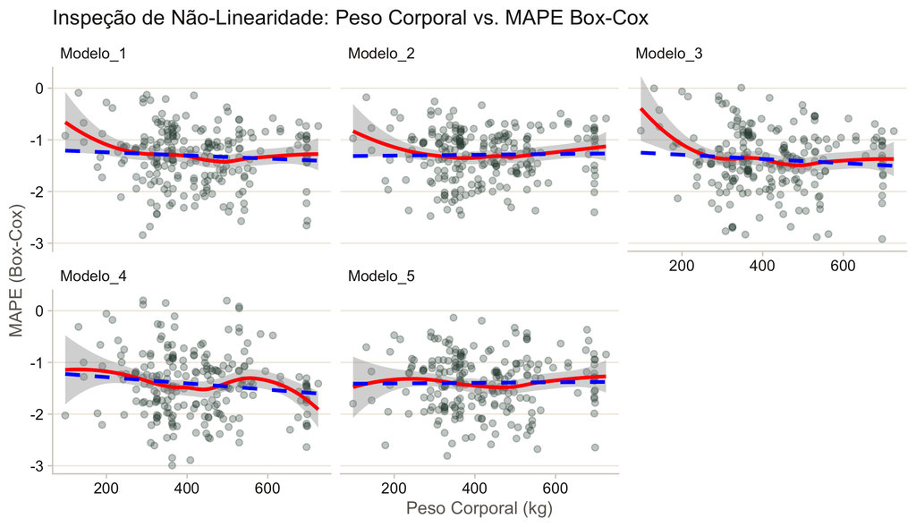

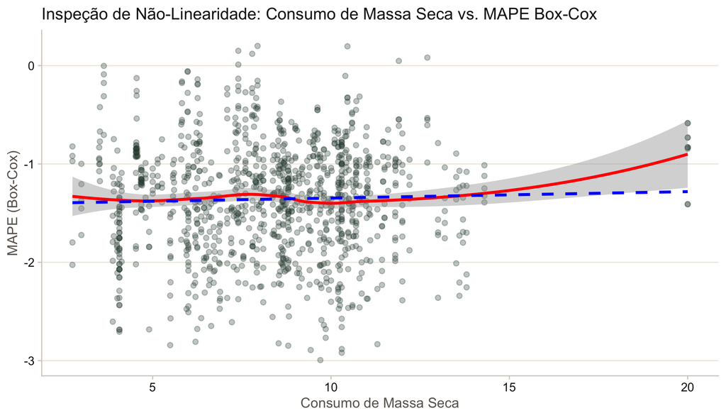

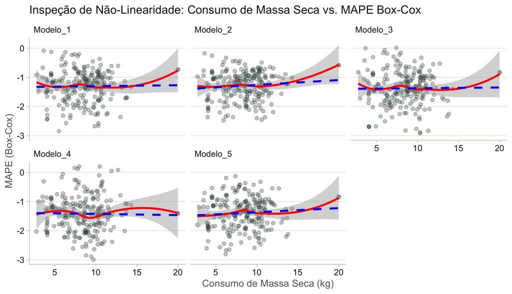

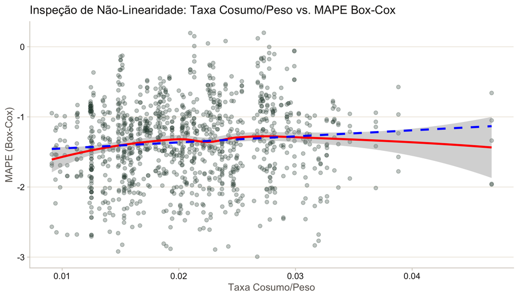

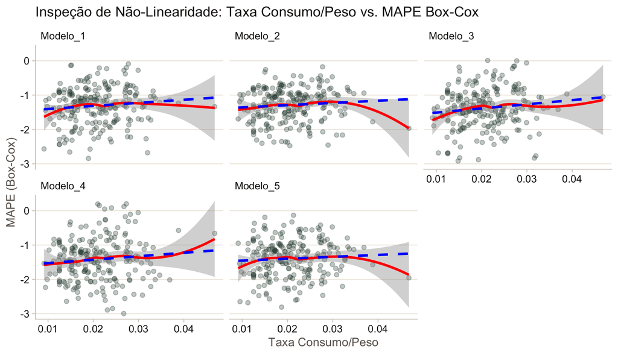

| Variável | Estatística F | p-valor | Δ AIC | Δ BIC | Decisão |
| --- | --- | --- | --- | --- | --- |
| Peso_Corporal_kg | 6.0607 | 0.000431 | -12.12 | 2.93 | Recomenda Spline |
| Consumo_MS_kg | 2.1094 | 0.097329 | -0.34 | 14.71 | Manter Linear |
| Fracao_Perda_A | 2.3057 | 0.075201 | -0.93 | 14.12 | Manter Linear |

Para comprovar formalmente a necessidade de B-Splines, é avaliada a significância da flexibilização não-linear através do **Teste de Razão de Verossimilhança (ANOVA)** e da comparação via **AIC e BIC**:

$$\text{H}_0: \text{A relação entre a
variável e o MAPE é estritamente linear } (\beta_2 = \beta_3 = \beta_4 =
0)$$
$$\text{H}_1: \text{Existe
componente não-linear significativo na relação}$$

- **Estatística $F$ e $p$-valor:** Avaliam se a redução no erro quadrático do modelo com spline é estatisticamente significante em relação ao modelo linear puro.
- **$\Delta$ AIC e $\Delta$ BIC:** Representam a diferença entre o modelo com spline e o modelo linear ($M_{\text{spline}} - M_{\text{linear}}$). Valores **negativos** indicam ganho de ajuste com penalização adequada da complexidade do modelo.

## 4.5 Representação Visual da Estratégia de Modelagem

O diagrama abaixo sintetiza todo o fluxo lógico percorrido pelos dados no script Python (`04_modelagem_validacao.py`), consolidando as decisões de tratamento e a estrutura em dois estágios:

```
flowchart TD
    %% Entrada e Grid Search
    D1["1. Entrada de Dados Processados
(03_modelagem.csv)
N = 1.115 observações pareadas | 223 Animais
Preditores Numéricos: Peso_Corporal_kg, Consumo_MS_kg, Fracao_Perda_A"]

    GS["2. Varredura Exaustiva de Features (Grid Search)
generate_feature_sets()
• Testa todas as combinações de variáveis numéricas e categóricas
• Avalia empiricamente o Consumo_MS_kg (tradeoff ganho vs VIF)
• Avalia B-Splines Cúbicas no Peso Corporal (4 nós)"]

    V1["3. Protocolos de Validação Cruzada (Sem Data Leakage)
• GroupKFold por Estudo (5 Folds)
• Leave-One-Study-Out (LOSO) nos 5 Países Ocultos (38 Estudos)
Estudo mantido estritamente como chave de agrupamento (vetado como feature)"]

    D1 --> GS
    GS --> V1

    %% Ramificação dos Estimadores
    V1 --> R1["RAMO A: Baseline Cego
baseline_predict()"]
    V1 --> R2["RAMO B: Estágio Único (Simples)
fit_predict_simples()"]
    V1 --> R3["RAMO C: Dois Estágios (2SLS)
fit_predict_2sls()"]

    %% Detalhes do Ramo A
    R1 --> A1["• Base: N = 1.115 linhas
• Preditores: Apenas Modelo
• Lógica: Mediana histórica por fórmula
• Saída: Predição constante"]

    %% Detalhes do Ramo B
    R2 --> B1["• Base: N = 1.115 linhas (Empilhada)
• Preditores: Combinações do Grid Search (num + cat)
• Lógica: OLS / Splines diretos em MAPE_boxcox
• Saída: inv_boxcox(y_hat)"]

    %% Detalhes do Ramo C
    R3 --> C1["• Base: n = 223 (E1) | N = 1.115 (E2)
• Preditores: Combinações do Grid Search
• Estágio 1: Prediz patamar do animal via X_animal
• Estágio 2: Prediz desvio da fórmula via Modelo
• Saída: inv_boxcox(P_i + D_j)"]

    %% Consolidação e Métricas
    A1 --> M1
    B1 --> M1
    C1 --> M1["5. Avaliação de Desempenho e Seleção Final
• Métricas Contínuas: MAE, RMSE e R² Out-of-Fold (OOF)
• Meta-Métrica de Ordenação: Acurácia Top-1 Ranking
• Incerteza: Bootstrap Clusterizado por Estudo (1.000 réplicas)"]

    style D1 fill:#EFF6FF,stroke:#1E3A8A,stroke-width:2px,color:#1E293B
    style GS fill:#FFFBEB,stroke:#D97706,stroke-width:2px,color:#1E293B
    style V1 fill:#F0FDFA,stroke:#0D9488,stroke-width:2px,color:#1E293B
    style R1 fill:#FEF3C7,stroke:#B45309,stroke-width:2px,color:#1E293B
    style R2 fill:#DBEAFE,stroke:#1D4ED8,stroke-width:2px,color:#1E293B
    style R3 fill:#F3E8FF,stroke:#6D28D9,stroke-width:2px,color:#1E293B
    style M1 fill:#ECFDF5,stroke:#047857,stroke-width:2px,color:#1E293B
```

**Figura 4.1 – Fluxograma do Pipeline Experimental de Modelagem, Grid Search e Validação Cruzada.**  
Fonte: Elaborado pelos autores com base na implementação do script `04_modelagem_validacao.py`.

**Legenda.**

- **Etapa 1 (Entrada de Dados):** carga do dataset processado (`03_modelagem.csv`) com *N* = 1.115 observações pareadas provenientes de 223 animais avaliados por 5 equações empíricas.
- **Etapa 2 (Grid Search de Features):** rotina `generate_feature_sets()`, testando combinações de covariáveis numéricas e categóricas, com avaliação do Consumo de Matéria Seca e da B-Spline Cúbica no Peso (4 nós).
- **Etapa 3 (Validação Cruzada Estrita):** `GroupKFold` (5 folds) e `Leave-One-Study-Out` (`LOSO` em 5 países ocultos), com `Estudo` apenas como chave de agrupamento.
- **Etapa 4 (Competição em Três Ramos):** baseline cego (`baseline_predict()`), estágio único (`fit_predict_simples()`) e dois estágios (`fit_predict_2sls()`).
- **Etapa 5 (Consolidação de Métricas):** avaliação OOF por MAE, RMSE, *R*<sup>2</sup>, Top-1 e Bootstrap Clusterizado por Estudo (1.000 réplicas).

[output not shown]

# 5 Resultados

## 5.1 A Dualidade Metodológica de Alvos

Existe uma diferença fundamental entre os dois alvos de avaliação do projeto:

1. **O Alvo (Métricas de Regressão Clássica):** Avalia a precisão pontual do valor do MAPE (*target*) via MAPE, MAE e $R^2$.
2. **O Alvo de Ordenação / Ranking (Acurácia Top-1):** Representa a meta-métrica do seletor. O algoritmo estima $\widehat{\text{MAPE}}_{ij}$ para selecionar a melhor formulação recomendada:

$$j^*_i = \arg\min_{j}
\widehat{\text{MAPE}}_{ij}$$

A avaliação final do projeto verifica o erro real produzido pela escolha $j^*_i$. A acurácia Top-1 mede exatamente a taxa em que o seletor acerta a equação (modelo empírico) de menor erro real no animal.

## 5.2 Avaliação do Alvo

A tabela abaixo apresenta os resultados consolidados pelo script Python (`04_metricas_resumo.csv`):

| protocolo | modelo | n_folds | n | mape | mae | rmse | r2 | top1 | top1_sempre_campeao |
| --- | --- | --- | --- | --- | --- | --- | --- | --- | --- |
| GroupKFold | ols_(sexo_modelo) | 5,000 | 1115,000 | 2,580 | 0,141 | 0,199 | -0,140 | 0,318 | 0,265 |
| GroupKFold | ols_(fracao)_(sexo_modelo) | 5,000 | 1115,000 | 2,581 | 0,141 | 0,198 | -0,130 | 0,318 | 0,265 |
| GroupKFold | ols_(modelo) | 5,000 | 1115,000 | 2,628 | 0,141 | 0,200 | -0,142 | 0,318 | 0,265 |
| GroupKFold | ols_(fracao)_(modelo) | 5,000 | 1115,000 | 2,629 | 0,141 | 0,199 | -0,137 | 0,318 | 0,265 |
| GroupKFold | ols_(status_sexo_modelo) | 5,000 | 1115,000 | 2,631 | 0,143 | 0,200 | -0,157 | 0,318 | 0,265 |
| GroupKFold | ols_(peso)_(sexo_modelo) | 5,000 | 1115,000 | 2,640 | 0,142 | 0,199 | -0,141 | 0,318 | 0,265 |
| GroupKFold | ols_(peso)_(status_sexo_modelo) | 5,000 | 1115,000 | 2,649 | 0,143 | 0,200 | -0,156 | 0,318 | 0,265 |
| GroupKFold | ols_(fracao)_(status_sexo_modelo) | 5,000 | 1115,000 | 2,649 | 0,143 | 0,200 | -0,158 | 0,318 | 0,265 |
| GroupKFold | ols_(consumo_fracao)_(sexo_modelo) | 5,000 | 1115,000 | 2,661 | 0,142 | 0,200 | -0,145 | 0,318 | 0,265 |
| GroupKFold | ols_(sexo) | 5,000 | 1115,000 | 2,663 | 0,142 | 0,199 | -0,140 | 0,117 | 0,265 |
| GroupKFold | ols_(consumo)_(pais_status_sexo_modelo) | 5,000 | 1115,000 | 2,924 | 0,155 | 0,214 | -0,365 | 0,318 | 0,265 |
| GroupKFold | ols_(consumo_fracao)_(pais_status_sexo_modelo) | 5,000 | 1115,000 | 2,956 | 0,156 | 0,215 | -0,372 | 0,318 | 0,265 |
| GroupKFold | baseline_mediana_modelo | 5,000 | 1115,000 | 2,960 | 0,140 | 0,194 | -0,079 | 0,265 | 0,265 |
| LOSO_paises_case | ols_(consumo)_(pais_status_sexo_modelo) | 38,000 | 375,000 | 1,984 | 0,118 | 0,137 | -3,063 | 0,413 | 0,413 |
| LOSO_paises_case | ols_(peso_consumo)_(pais_status_sexo_modelo) | 38,000 | 375,000 | 1,993 | 0,118 | 0,137 | -3,080 | 0,413 | 0,413 |
| LOSO_paises_case | ols_(consumo)_(pais_status_sexo) | 38,000 | 375,000 | 2,007 | 0,119 | 0,138 | -3,095 | 0,093 | 0,413 |
| LOSO_paises_case | ols_(consumo_fracao)_(pais_status_sexo_modelo) | 38,000 | 375,000 | 2,013 | 0,118 | 0,137 | -3,029 | 0,413 | 0,413 |
| LOSO_paises_case | ols_(peso_consumo)_(pais_status_sexo) | 38,000 | 375,000 | 2,017 | 0,119 | 0,138 | -3,111 | 0,093 | 0,413 |
| LOSO_paises_case | ols_(peso_fracao)_(pais_status_sexo_modelo) | 38,000 | 375,000 | 2,018 | 0,115 | 0,135 | -2,952 | 0,413 | 0,413 |
| LOSO_paises_case | ols_(peso_consumo_fracao)_(pais_status_sexo_modelo) | 38,000 | 375,000 | 2,033 | 0,116 | 0,136 | -3,015 | 0,413 | 0,413 |
| LOSO_paises_case | ols_(consumo_fracao)_(pais_status_sexo) | 38,000 | 375,000 | 2,036 | 0,119 | 0,138 | -3,061 | 0,093 | 0,413 |
| LOSO_paises_case | ols_(peso_fracao)_(pais_status_sexo) | 38,000 | 375,000 | 2,042 | 0,116 | 0,136 | -2,985 | 0,093 | 0,413 |
| LOSO_paises_case | ols_(peso_consumo_fracao)_(pais_status_sexo) | 38,000 | 375,000 | 2,057 | 0,117 | 0,137 | -3,048 | 0,093 | 0,413 |
| LOSO_paises_case | ols_(peso)_(status_sexo_modelo) | 38,000 | 375,000 | 2,295 | 0,106 | 0,124 | -2,132 | 0,413 | 0,413 |
| LOSO_paises_case | ols_(fracao)_(status_sexo_modelo) | 38,000 | 375,000 | 2,315 | 0,108 | 0,126 | -2,209 | 0,413 | 0,413 |
| LOSO_paises_case | ols_(status_sexo_modelo) | 38,000 | 375,000 | 2,345 | 0,107 | 0,124 | -2,199 | 0,413 | 0,413 |
| LOSO_paises_case | ols_(peso)_(sexo_modelo) | 38,000 | 375,000 | 2,400 | 0,103 | 0,120 | -1,871 | 0,413 | 0,413 |
| LOSO_paises_case | ols_(consumo_fracao)_(sexo_modelo) | 38,000 | 375,000 | 2,402 | 0,105 | 0,122 | -1,935 | 0,413 | 0,413 |
| LOSO_paises_case | ols_(fracao)_(sexo_modelo) | 38,000 | 375,000 | 2,429 | 0,106 | 0,123 | -1,974 | 0,413 | 0,413 |
| LOSO_paises_case | ols_(sexo_modelo) | 38,000 | 375,000 | 2,497 | 0,105 | 0,122 | -1,984 | 0,413 | 0,413 |
| LOSO_paises_case | ols_(sexo) | 38,000 | 375,000 | 2,525 | 0,107 | 0,124 | -2,013 | 0,093 | 0,413 |
| LOSO_paises_case | ols_(modelo) | 38,000 | 375,000 | 2,760 | 0,107 | 0,123 | -1,805 | 0,413 | 0,413 |
| LOSO_paises_case | ols_(fracao)_(modelo) | 38,000 | 375,000 | 2,776 | 0,108 | 0,124 | -1,808 | 0,413 | 0,413 |
| LOSO_paises_case | baseline_mediana_modelo | 38,000 | 375,000 | 3,189 | 0,108 | 0,124 | -1,747 | 0,413 | 0,413 |

### 5.2.1 Gráfico de resíduos OOF (Homocedasticidade e Q-Q Plot)

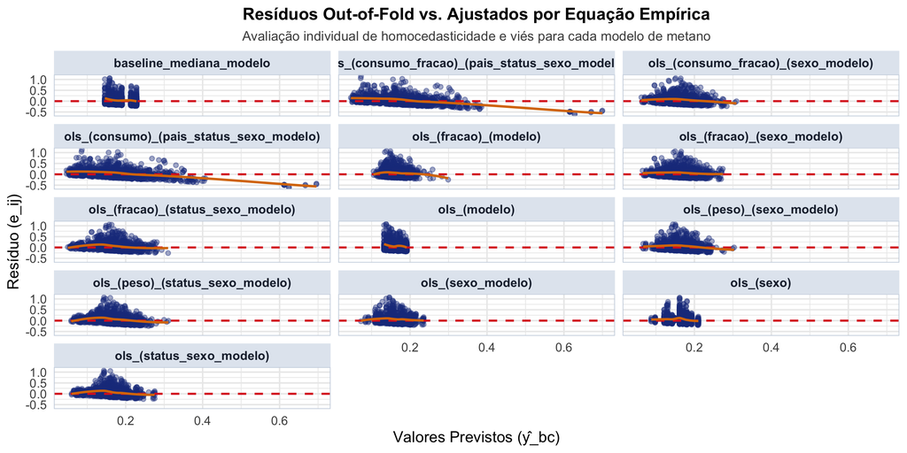

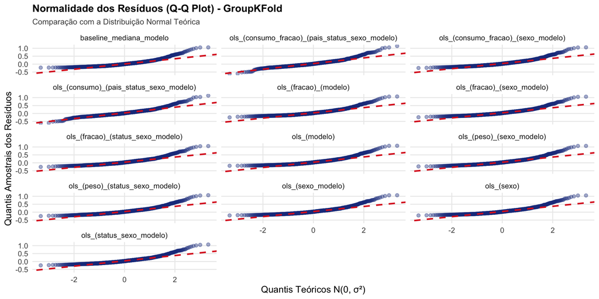

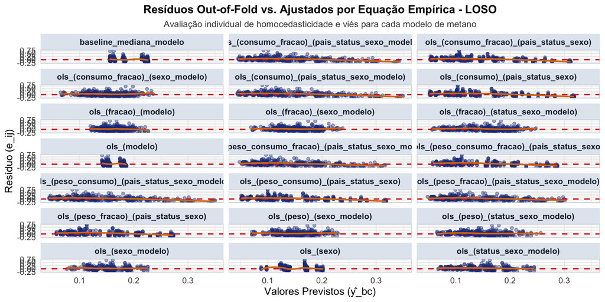

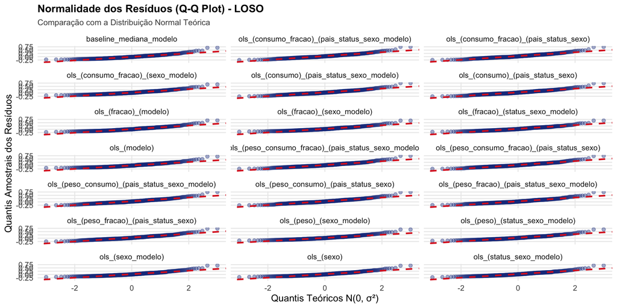

## 5.3 Avaliação de Incerteza via Bootstrap Clusterizado por Estudo

Realizou-se uma simulação de **Bootstrap Clusterizado por Estudo (1.000 réplicas)** para avaliar os erros Out-of-Fold:

IC 95% do MAE e do RMSE via bootstrap agrupado por Estudo (OOF do GroupKFold, 1.000 réplicas).

| protocolo | modelo | n_boot | agrupamento | mape | mape_ic95_inf | mape_ic95_sup | mae | mae_ic95_inf | mae_ic95_sup | rmse | rmse_ic95_inf | rmse_ic95_sup |
| --- | --- | --- | --- | --- | --- | --- | --- | --- | --- | --- | --- | --- |
| GroupKFold | ols_(sexo_modelo) | 1000,000 | Estudo | 2,580 | 1,870 | 3,331 | 0,141 | 0,121 | 0,165 | 0,204 | 0,171 | 0,241 |
| GroupKFold | ols_(fracao)_(sexo_modelo) | 1000,000 | Estudo | 2,581 | 1,851 | 3,466 | 0,141 | 0,120 | 0,162 | 0,203 | 0,167 | 0,237 |
| GroupKFold | ols_(modelo) | 1000,000 | Estudo | 2,628 | 1,918 | 3,468 | 0,141 | 0,121 | 0,165 | 0,205 | 0,169 | 0,241 |
| GroupKFold | ols_(fracao)_(modelo) | 1000,000 | Estudo | 2,629 | 1,914 | 3,454 | 0,141 | 0,122 | 0,164 | 0,204 | 0,171 | 0,241 |
| GroupKFold | ols_(status_sexo_modelo) | 1000,000 | Estudo | 2,631 | 1,853 | 3,492 | 0,143 | 0,124 | 0,167 | 0,204 | 0,169 | 0,241 |
| GroupKFold | ols_(peso)_(sexo_modelo) | 1000,000 | Estudo | 2,640 | 1,792 | 3,572 | 0,142 | 0,122 | 0,165 | 0,204 | 0,169 | 0,238 |
| GroupKFold | ols_(peso)_(status_sexo_modelo) | 1000,000 | Estudo | 2,649 | 1,913 | 3,544 | 0,143 | 0,125 | 0,165 | 0,204 | 0,173 | 0,240 |
| GroupKFold | ols_(fracao)_(status_sexo_modelo) | 1000,000 | Estudo | 2,649 | 1,844 | 3,626 | 0,143 | 0,125 | 0,165 | 0,204 | 0,170 | 0,238 |
| GroupKFold | ols_(consumo_fracao)_(sexo_modelo) | 1000,000 | Estudo | 2,661 | 1,878 | 3,672 | 0,142 | 0,124 | 0,164 | 0,204 | 0,171 | 0,238 |
| GroupKFold | ols_(sexo) | 1000,000 | Estudo | 2,663 | 1,841 | 3,503 | 0,142 | 0,123 | 0,166 | 0,204 | 0,172 | 0,241 |
| GroupKFold | ols_(consumo)_(pais_status_sexo_modelo) | 1000,000 | Estudo | 2,924 | 1,979 | 3,995 | 0,155 | 0,135 | 0,177 | 0,216 | 0,183 | 0,251 |
| GroupKFold | ols_(consumo_fracao)_(pais_status_sexo_modelo) | 1000,000 | Estudo | 2,956 | 1,978 | 4,009 | 0,156 | 0,135 | 0,180 | 0,217 | 0,181 | 0,255 |
| GroupKFold | baseline_mediana_modelo | 1000,000 | Estudo | 2,960 | 2,098 | 3,953 | 0,140 | 0,122 | 0,164 | 0,198 | 0,165 | 0,237 |

# 6 Anexos